# Assignment 0

Michael Nguyen - https://github.com/MoreExcuses

January 27, 2016

Seneca ID: 042556142

### Objective

We are to go through the document: https://cran.r-project.org/doc/contrib/Torfs+Brauer-Short-R-Intro.pdf and complete the 14 To-do sections as well as the last bonus one in the footnotes of To-Do 14

### 3.1 Calculator

```r
(2014-2014)/(2014-1992)*100
```

```
## [1] 0
```

### 3.2 Workspace

```r
a <- 2014-2014
b <- 2014-1992
c <- 100

a/b*c
```

```
## [1] 0
```

### 3.4 Functions

```r
b = c(4,5,8,11)

sum(c)
```

```
## [1] 100
```

### 3.5 Plots

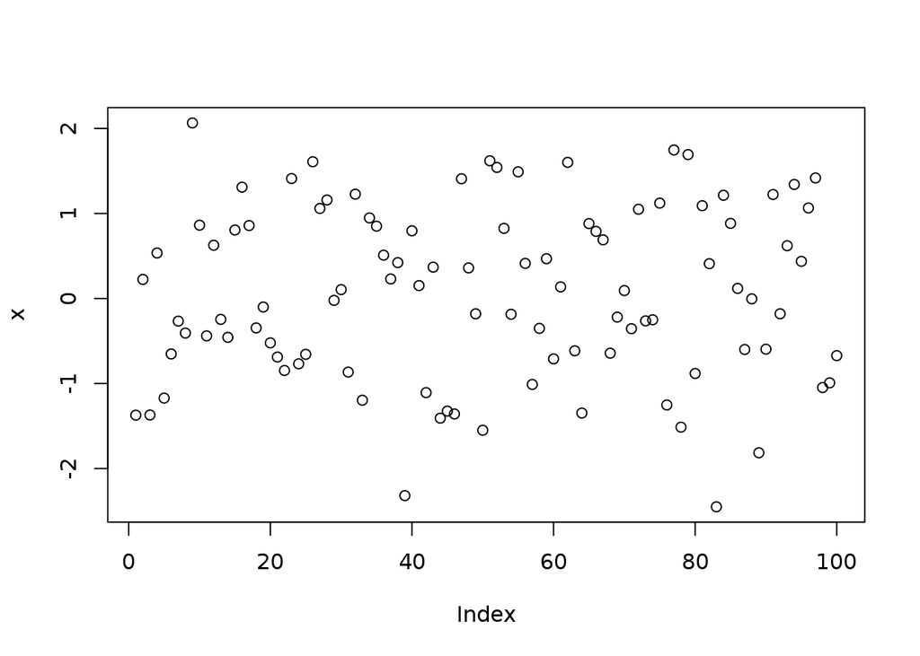

```r
x=rnorm(100)
plot(x)
```

### 4 Help and Documentation

```r
help(sqrt)
```

### 5 Scripts

```r
source("firstscript.R")
```

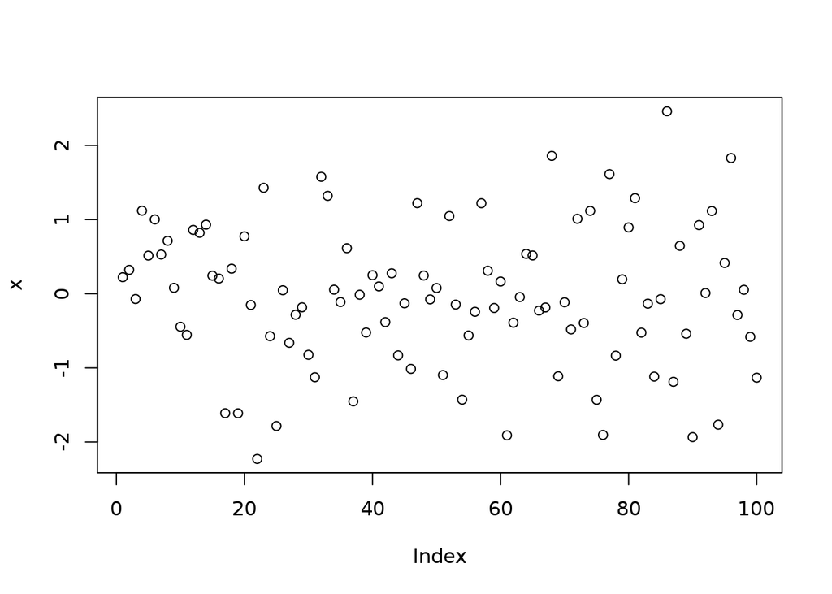

```r
source("firstscript.R")
```

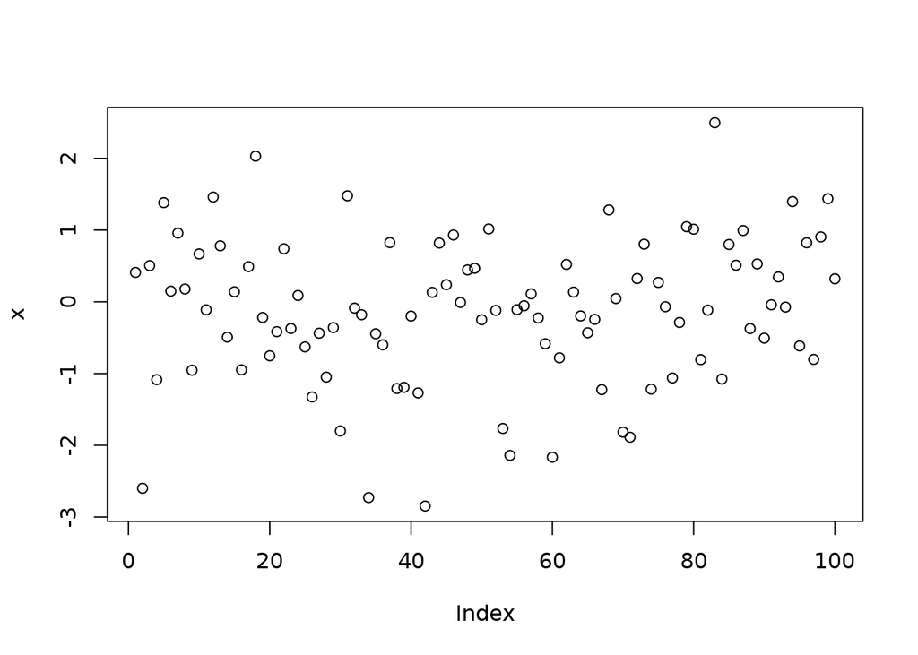

```r
source("firstscript.R")
```

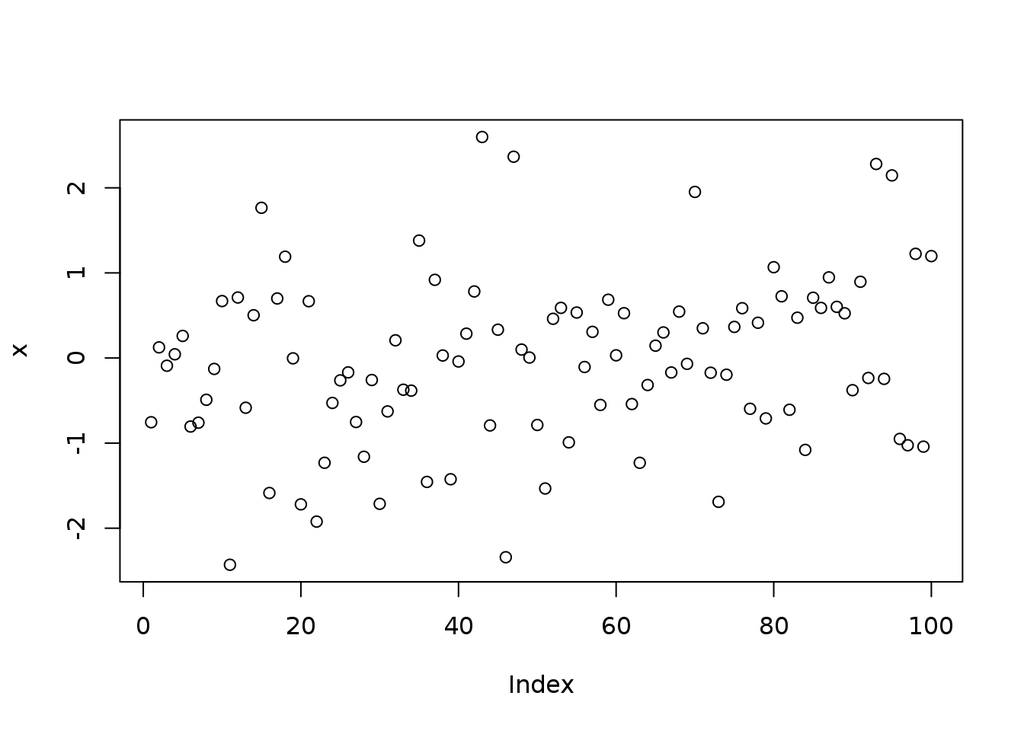

### 6.2 Matrices

```r
P = seq(from=31, to=60)

Q=matrix(data=P,ncol=5)
```

### 6.3 Data Frames

```r
source("dataframe.R")
```

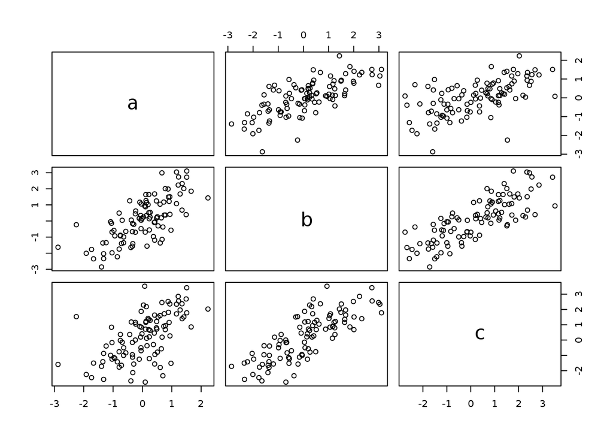

Contents of dataframe.R

dataframe.R

x1 = c(rnorm(100))

x2 = c(rnorm(100))

x3 = c(rnorm(100))

t = data.frame(a=x1,b=(x1+x2),c=(x1+x2+x3))

plot(t)

sd has been deprecated and you can use the below line instead sapply(t, sd)

# 7. Graphics

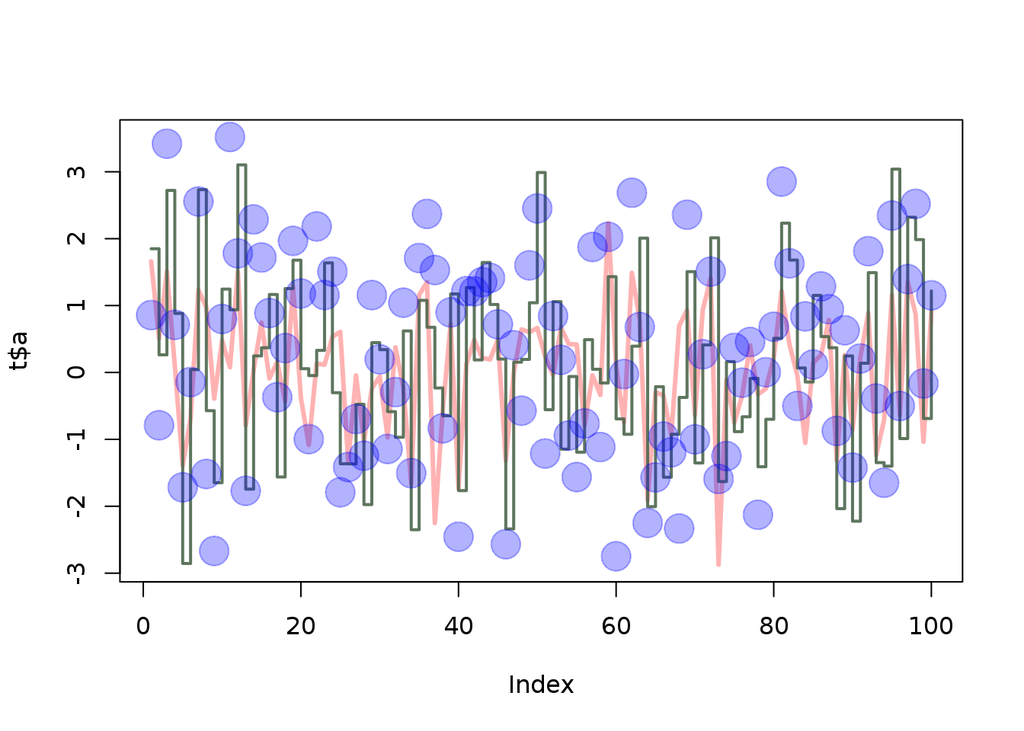

```r
x1 = c(rnorm(100))
x2 = c(rnorm(100))
x3 = c(rnorm(100))

plot(t$a, type="l", ylim=range(t),lwd=3, col=rgb(1,0,0,0.3))
lines(t$b, type="s", lwd=2,
col=rgb(0.3,0.4,0.3,0.9))
points(t$c, pch=20, cex=4,
col=rgb(0,0,1,0.3))
```

1. rgb is setting color with r meaning red, g meaning green and b meaning blue
2. the last argument in this for rgb stands for alpha. When alpha is less than 1 and greater than 0, they will appear as semi-transparent
3. lwd stands for line width
4. pch allows you to either specify and integer or single character to be used as a plotting point.
5. cex is a numerical value giving the amount by which text and symbols will be magnified relative to default.

### 8. Reading and writing data files

d = data.frame(a = c(1,2,4,8,16,32), g = c(2,4,8,16,32,64), x = c(3,6,12,24,48,96)) write.table(d,file=“tst1.txt” , row.names.data.frame())

```r
d1 = read.table(file="tst1.txt", header=TRUE)
d2 = d1$g*5
write.table(d2, file="tst2.txt" , row.names=FALSE)
```

### 9 Not available Data

```r
vec=c(rnorm(100))
mean(sqrt(vec))
```

```
## [1] NaN
```

Unable to work because we produce Not a Number results, (imaginary quantities)

### 10 Classes

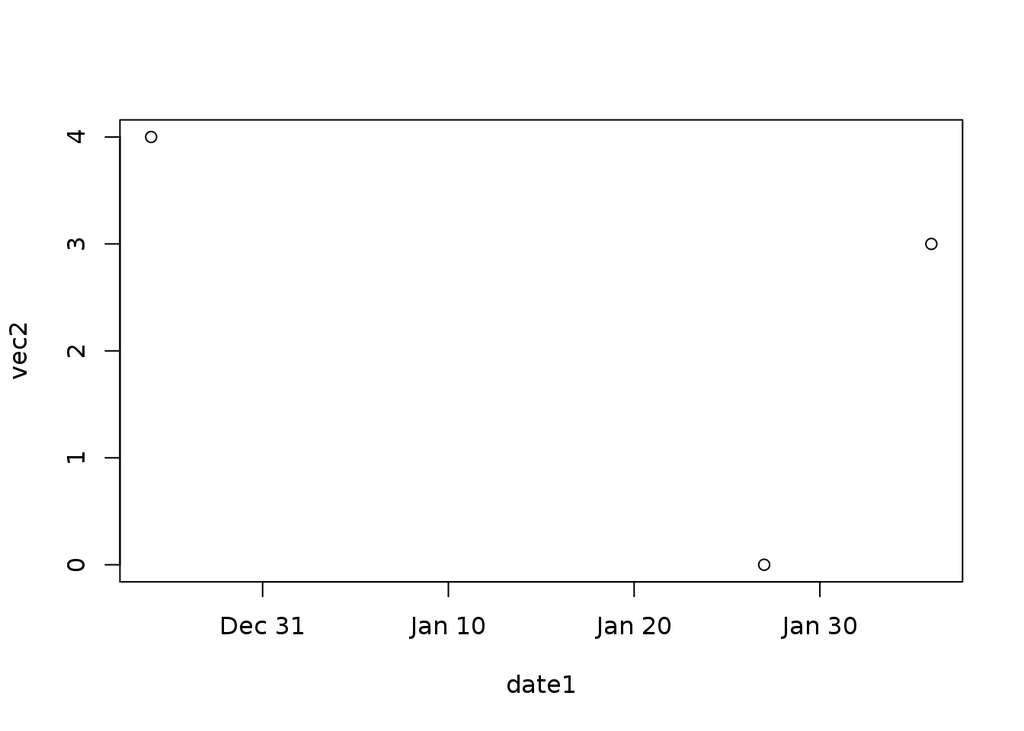

```r
date1=strptime( c("20160127","20160205","20151225"),format="%Y%m%d")
vec2 = c(0,3,4)
plot(x=date1,y=vec2,type = "p")
```

### 11.2 For Loop

```r
h=c(1:100)
vec=c()

for(i in h){
  if( i < 5 || i > 90)
  {
  vec[i]=i*10
  }
  else
  {
  vec[i]=i*0.1
  }
}
vec
```

```
##   [1]   10.0   20.0   30.0   40.0    0.5    0.6    0.7    0.8    0.9    1.0
##  [11]    1.1    1.2    1.3    1.4    1.5    1.6    1.7    1.8    1.9    2.0
##  [21]    2.1    2.2    2.3    2.4    2.5    2.6    2.7    2.8    2.9    3.0
##  [31]    3.1    3.2    3.3    3.4    3.5    3.6    3.7    3.8    3.9    4.0
##  [41]    4.1    4.2    4.3    4.4    4.5    4.6    4.7    4.8    4.9    5.0
##  [51]    5.1    5.2    5.3    5.4    5.5    5.6    5.7    5.8    5.9    6.0
##  [61]    6.1    6.2    6.3    6.4    6.5    6.6    6.7    6.8    6.9    7.0
##  [71]    7.1    7.2    7.3    7.4    7.5    7.6    7.7    7.8    7.9    8.0
##  [81]    8.1    8.2    8.3    8.4    8.5    8.6    8.7    8.8    8.9    9.0
##  [91]  910.0  920.0  930.0  940.0  950.0  960.0  970.0  980.0  990.0 1000.0
```

### 11.3 Writing your own functions

```r
fun1= function(arg1)
{
  newVec=c()
  for(i in 1:length(arg1)){
    if( arg1[i] < 5 || arg1[i] > 90)
    {
      newVec[i]=arg1[i]*10
    }
    else
    {
      newVec[i]=arg1[i]*0.1
    }
  }
  return (newVec)
}
vec5=c(1,2,3,6,9,91)
vec6=fun1(vec5)
```

### Bonus

R similarily to Mathlab is slower at computing for loops. R also performs vector math much faster since it only needs to ask what type of data are in each vector (sees 2 things) rather than each element in the vector(x things). This is known as vectorization and is core for new R programmers to learn in order to make code more efficient.

```r
test = c(1,2,3,4,5,90,91,77,43,2,1)


fun2= function(vec)
{
ifelse(vec < 5 | vec > 90, vec * 10, vec * 0.1)
}
fun2(test)
```

```
##  [1]  10.0  20.0  30.0  40.0   0.5   9.0 910.0   7.7   4.3  20.0  10.0
```

### Getting knitr

install.packages(“knitr”)

In order to use the markdown language we must make the file an .rmd extension and fix it using the cheat sheet which is listed in the sources

### Sources

http://www.noamross.net/blog/2014/4/16/vectorization-in-r–why.html

http://rpubs.com/daspringate/vectorisation

https://www.rstudio.com/wp-content/uploads/2015/02/rmarkdown-cheatsheet.pdf